# Chapter 2 - Regression analysis using R

After managing to create a working dataframe containing the variables of interest and saving it to a local .csv-file I’m now ready to start analyzing.

Step one of any analysis for me is to get to know the data. To start off with I’ll run

```r
learning2014 <- read.csv("./data/learning2014.csv")
head(learning2014)
```

```
##   age attitude points gender deep stra surf
## 1  53       37     25      F   43   27   31
## 2  55       31     12      M   35   22   38
## 3  49       25     24      F   42   29   27
## 4  53       35     10      M   42   25   27
## 5  49       37     22      M   44   29   34
## 6  38       38     21      F   57   29   29
```

So now I know what variables I’m working with and something about the scale. The names of the variables refer to the age of the participants, their attitudes towards statistics (as measured by SATS [(Survey of Attitudes Toward Statistics)](http://www.evaluationandstatistics.com/)), their exam points, their gender and approaches to studying (deep learning, strategy use and surface learning) - respectively. The last three variables are sum scores of items representing the named dimensions. These were measured using ASSIST B [(Approaches and Study Skills Inventory for Students)](http://www.etl.tla.ed.ac.uk/questionnaires/ASSIST.pdf).

Next I’ll want to know more about my data, namely the number of observations I’m working with, so I’ll run

```r
dim(learning2014)
```

```
## [1] 166   7
```

Ok, so I’ve got 166 observations of the above mentioned seven variables. Next I’ll pull up some descriptive statistics

```r
summary(learning2014)
```

```
##       age           attitude         points      gender       deep
##  Min.   :17.00   Min.   :14.00   Min.   : 7.00   F:110   Min.   :19.00
##  1st Qu.:21.00   1st Qu.:26.00   1st Qu.:19.00   M: 56   1st Qu.:40.00
##  Median :22.00   Median :32.00   Median :23.00           Median :44.00
##  Mean   :25.51   Mean   :31.43   Mean   :22.72           Mean   :44.16
##  3rd Qu.:27.00   3rd Qu.:37.00   3rd Qu.:27.75           3rd Qu.:49.00
##  Max.   :55.00   Max.   :50.00   Max.   :33.00           Max.   :59.00
##       stra            surf
##  Min.   :10.00   Min.   :19.00
##  1st Qu.:21.00   1st Qu.:29.00
##  Median :25.50   Median :34.00
##  Mean   :24.97   Mean   :33.45
##  3rd Qu.:29.00   3rd Qu.:38.00
##  Max.   :40.00   Max.   :52.00
```

This tells me a bit more about the data. About two thirds of the participants were female, the youngest participant was 17 and the oldest 55. The mean and median age was quite a bit younger than yours truly would have been in 2014, but what the hey…

Time to get graphical. This is an important part of getting to know the data, because when studying the graphs you can quickly spot if something in the data is off.

In R it’s easy to (relatively) quickly draw some plots to get an overview of the data using:

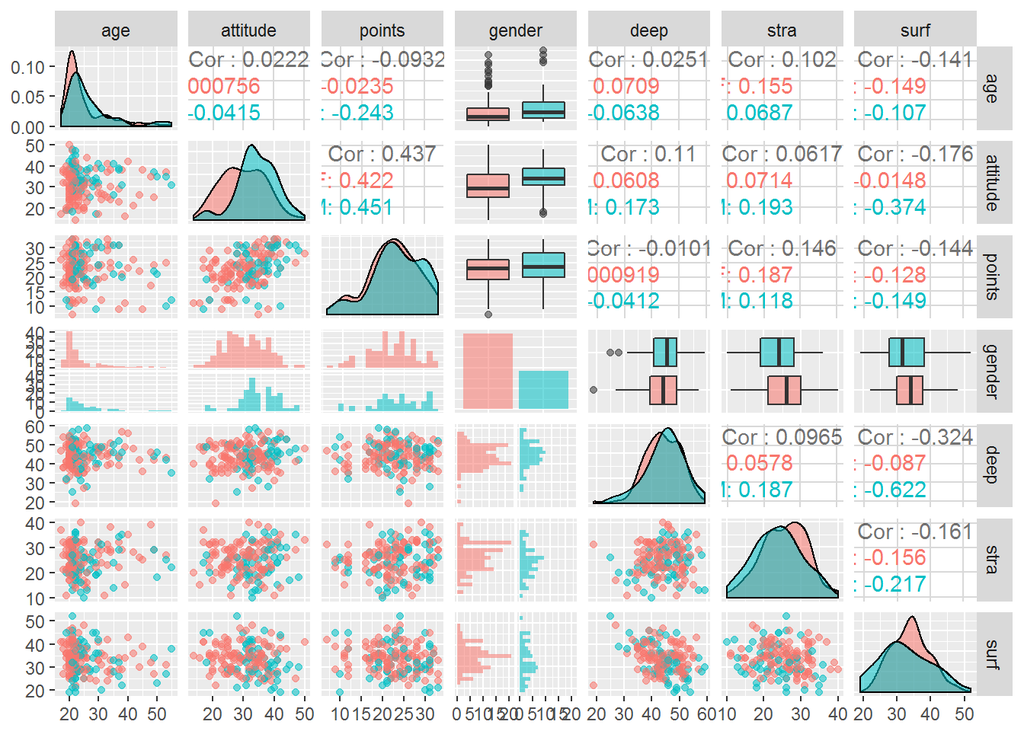

```r
library(GGally)
library(ggplot2)

p <- ggpairs(learning2014, mapping = aes(col = gender, alpha = 0.3), lower = list(combo = wrap("facethist", bins = 20)))
p
```

With the data plotted I can draw some conclusions regarding the data. First of all (except for age) most variables show some approximation of a normal distribution. We also see that some of the variables contain quite obivious outliers, we’ll get back to those later I guess. We also get a set of correlations. In this plot matrix I’ve color coded for gender, so we can read total correlations and correlations by gender. From these we can roughly see for example which variables correlate with total amount of points. The strongest absolute correlates with points are *attitude* (.437), *strategy* (.146) and *surface* learning (-.144).

```r
model1 <- lm(points ~ attitude + deep + surf, data = learning2014)
summary(model1)
```

```
##
## Call:
## lm(formula = points ~ attitude + deep + surf, data = learning2014)
##
## Residuals:
##      Min       1Q   Median       3Q      Max
## -16.9168  -3.1487   0.3667   3.8326  11.3519
##
## Coefficients:
##             Estimate Std. Error t value Pr(>|t|)
## (Intercept) 18.35507    4.71237   3.895 0.000143 ***
## attitude     0.34661    0.05766   6.011 1.18e-08 ***
## deep        -0.07904    0.06585  -1.200 0.231815
## surf        -0.09093    0.06967  -1.305 0.193669
## ---
## Signif. codes:  0 '***' 0.001 '**' 0.01 '*' 0.05 '.' 0.1 ' ' 1
##
## Residual standard error: 5.313 on 162 degrees of freedom
## Multiple R-squared:  0.2024, Adjusted R-squared:  0.1876
## F-statistic:  13.7 on 3 and 162 DF,  p-value: 5.217e-08
```

Alright, so of these variables only attitude seems to explain points at a statistically significant level: $(\beta = .35, p < 0.001).$

Now I’ll create a new model removing the non-significant variables. This gives us the following simple regression:

```r
model2 <- lm(points ~ attitude, data = learning2014)
summary(model2)
```

```
##
## Call:
## lm(formula = points ~ attitude, data = learning2014)
##
## Residuals:
##      Min       1Q   Median       3Q      Max
## -16.9763  -3.2119   0.4339   4.1534  10.6645
##
## Coefficients:
##             Estimate Std. Error t value Pr(>|t|)
## (Intercept) 11.63715    1.83035   6.358 1.95e-09 ***
## attitude     0.35255    0.05674   6.214 4.12e-09 ***
## ---
## Signif. codes:  0 '***' 0.001 '**' 0.01 '*' 0.05 '.' 0.1 ' ' 1
##
## Residual standard error: 5.32 on 164 degrees of freedom
## Multiple R-squared:  0.1906, Adjusted R-squared:  0.1856
## F-statistic: 38.61 on 1 and 164 DF,  p-value: 4.119e-09
```

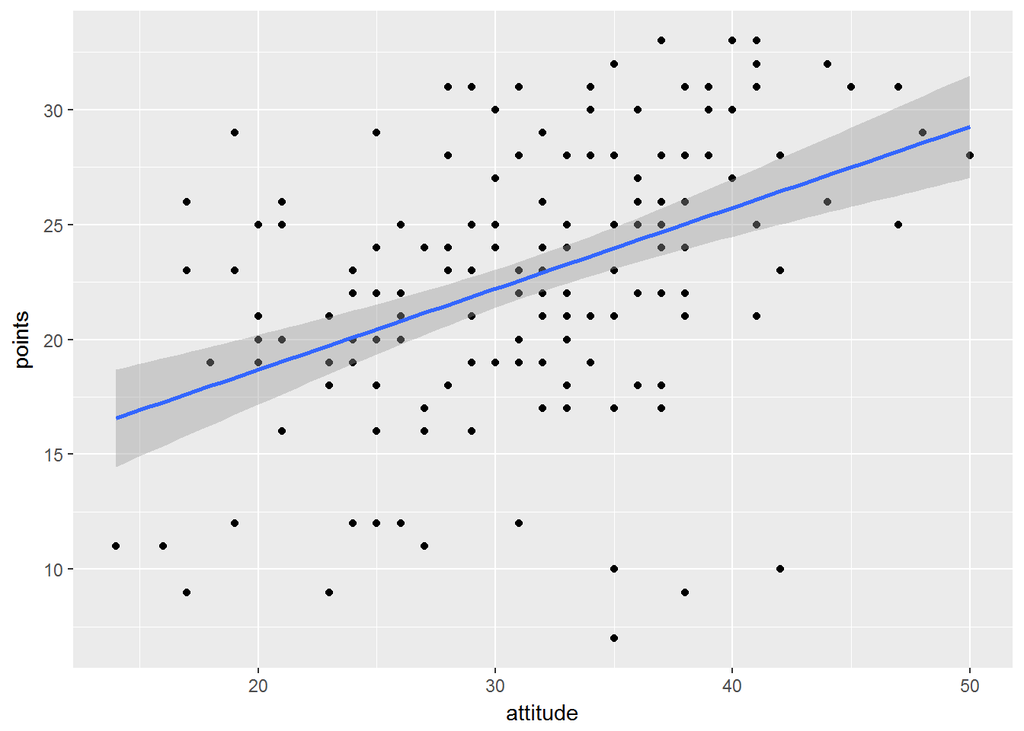

```r
qplot(attitude, points, data = learning2014) + geom_smooth(method = "lm")
```

Now I still need to check that my data doesn’t violate the assumptions of the model. The residuals look quite alright. To make sure I’ll run some plots:

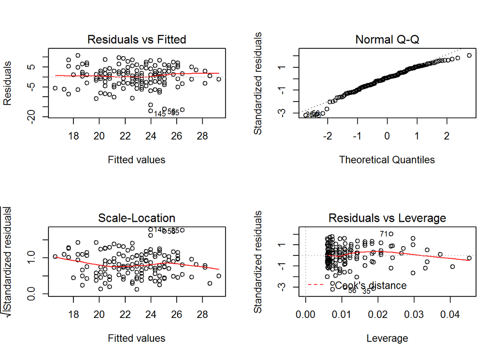

```r
par(mfrow = c(2,2))
plot(model2)
```

To my eye this seems rather OK. There are a few outliers that seem to have some leverage and if I were a bit more worried about these I could remove them and rerun the model. However I feel OK with interpreting the results as they are. I also feel confident that our data does not violate the assumptions of the model since there is no indication of a non-linear relationship and the errors are normally distributed.